# ABD_2001-2024_Gasoline-Prices-Visualization-Analysis

# Aylık Benzin Fiyatlarının Dağılımı

### Box Plot

- Aylık benzin fiyatlarının yıllar içindeki dağılımını gösterir.
- Fiyatların yılın farklı aylarındaki varyasyonlarını analiz etmek için kullanışlıdır.

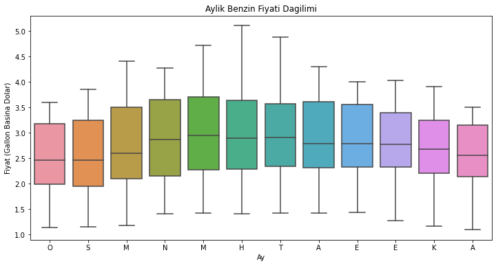

```python
plt.figure(figsize=(12, 6))
fuel_Prices['Month'] = pd.to_datetime(fuel_Prices['Date']).dt.month
monthly_prices = fuel_Prices[['Month', 'Weekly U.S. All Grades All Formulations Retail Gasoline Prices  (Dollars per Gallon)']]
sns.boxplot(data=monthly_prices, x='Month', y='Weekly U.S. All Grades All Formulations Retail Gasoline Prices  (Dollars per Gallon)')
plt.title('Aylik Benzin Fiyati Dagilimi')
plt.xlabel('Ay')
plt.ylabel('Fiyat (Gallon Basina Dolar)')
plt.xticks(range(12), ['O', 'S', 'M', 'N', 'M', 'H', 'T', 'A', 'E', 'E', 'K', 'A'])
plt.show()
```

Her bir kutu, o ay için fiyatların medyanını (kutu içindeki kalın çizgi), çeyrekler arası aralığı (kutu sınırları) ve dış çeyreklerden daha uç değerlere kadar olan aralığı (çizgiler) temsil eder. Kutuların genişlikleri, her ayın fiyat dağılımını görselleştirir.

Grafik genel olarak, bazı aylar diğerlerinden daha geniş bir fiyat aralığına sahip olabilir, bu da o dönemde fiyatlarda daha büyük dalgalanmalar olduğunu gösterir.

# Benzin ve Dizel Fiyatlarının Zaman İçindeki Değişimi

### Çoklu Zaman Serisi Grafiği

- ABD'deki benzin ve dizel fiyatlarının zaman içindeki değişimini görselleştirir.

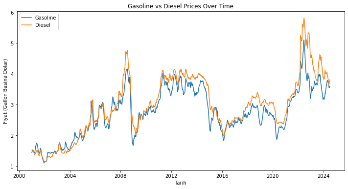

```python
plt.figure(figsize=(12, 6))
sns.lineplot(data=fuel_Prices, x='Date', y='Weekly U.S. All Grades All Formulations Retail Gasoline Prices  (Dollars per Gallon)', label='Gasoline')
sns.lineplot(data=fuel_Prices, x='Date', y='Weekly U.S. No 2 Diesel Retail Prices  (Dollars per Gallon)', label='Diesel')
plt.title('Gasoline vs Diesel Prices Over Time')
plt.xlabel('Tarih')
plt.ylabel('Fiyat (Gallon Basina Dolar)')
plt.legend()
plt.show()
```

- **Genel Trendler:** Benzin ve dizel fiyatlarının genel eğilimlerini inceleyebiliriz.
- **Fiyat Dalgalanmaları:** Her iki yakıt türünde de belirgin dalgalanmalar görülmektedir, özellikle 2008 ve 2020 yıllarında.
- **Yakıt Türleri Arasındaki Fark:** Benzin ve dizel fiyatlarının nasıl değiştiğini ve bu iki yakıt türü arasındaki fiyat farkını gözlemleyebiliriz.

# Isı Haritası

- Verilerin yoğunluğunu veya değerlerini renklerle görselleştiren bir grafik türüdür.
- Isı haritasında, renkler belirli bir değer aralığını temsil eder.
- Normal veri dağılımından sapmaları veya anormal durumları belirlemek için kullanılır. Renk farklılıkları sayesinde aykırı değerler veya anomaliler hemen fark edilebilir.
- Verilerin hangi bölgelerde yoğunlaştığını veya belirli değerlerin ne kadar sık gerçekleştiğini görselleştirir. Örneğin, satış verileri analiz edilirken sık kullanılan bir yöntemlerden bir tanesidir.

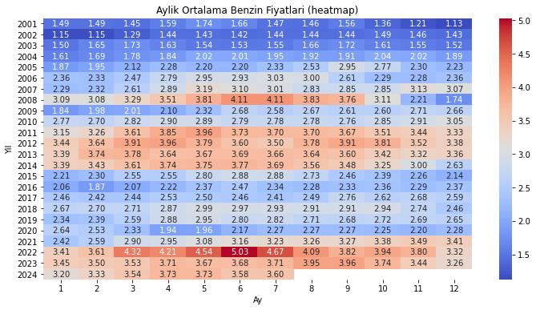

```python
plt.figure(figsize=(12, 6))
fuel_Prices['Month'] = fuel_Prices['Date'].dt.month
monthly_avg_price = fuel_Prices.groupby(['Year', 'Month'])['Weekly U.S. All Grades All Formulations Retail Gasoline Prices  (Dollars per Gallon)'].mean().unstack()
sns.heatmap(monthly_avg_price, cmap='coolwarm', annot=True, fmt='.2f')
plt.title('Aylik Ortalama Benzin Fiyatlari (heatmap)')
plt.xlabel('Ay')
plt.ylabel('Yil')
plt.show()
```

  ```
    - Yıllar içindeki genel fiyat eğilimlerini ve uzun dönemli trendleri gözlemleyebiliriz.
    - Yıllar içinde belirli dönemlerde fiyatların nasıl dalgalandığını gözlemleyebiliriz.
    - 2008, 2014 ve 2020 yıllardaki olayların etkilerini inceleyebiliriz.
  ```